# Preliminary analysis of Giedd dataset

John Lee

date()

After loading the appropriate R packages the data is loaded.

The aseg.stats files are found by searching all files in the subjects directory. In searching 1193 subjects, 1193 stats files were found.

## A quick look at some metadata

A quick summary of the number of distinct values for each variable is shown below (this makes little sense for continuous variables of course):

```
## Classes 'tbl_df', 'tbl' and 'data.frame':    1 obs. of  26 variables:
##  $ fam_ID             : int 393
##  $ num_from_family    : int 5
##  $ MRN                : int 545
##  $ person_num_scans   : int 9
##  $ person_start_age   : int 475
##  $ person_age_diff    : int 292
##  $ scan_id            : int 1254
##  $ calibration_studies: int 3
##  $ scan_format        : int 3
##  $ scanner            : int 5
##  $ scanner_text       : int 5
##  $ scan_seq_for_person: int 4
##  $ family             : int 134
##  $ LN                 : int 135
##  $ FN                 : int 115
##  $ sex                : int 2
##  $ race_fed           : int 5
##  $ ethnicity          : int 2
##  $ junk               : int 144
##  $ date_of_scan       : int 597
##  $ age_at_scan        : int 934
##  $ plane              : int 2
##  $ raw_qc             : int 3
##  $ post_mni_qc        : int 32
##  $ post_M_C_qc        : int 4
##  $ qc_ok              : int 2
```

A plot of some of the categorical variables gives a quick overview of the data:

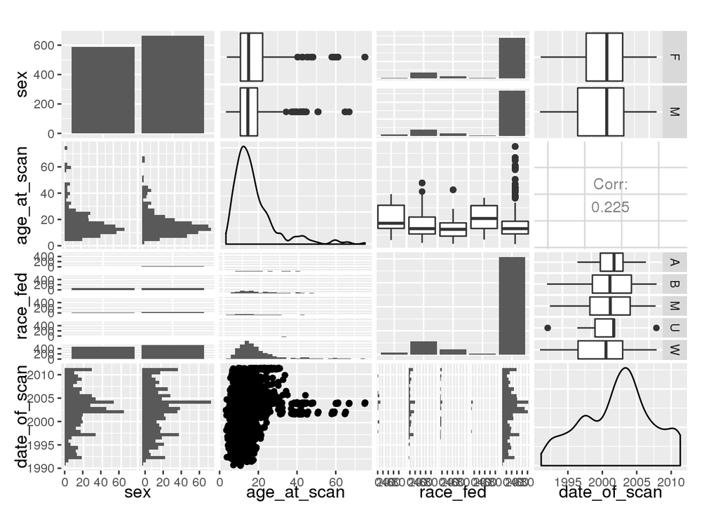

Metadata exists for every subject dataset. Quality control for 319 subjects is not complete. A plot is included below of the data for both raw and post MNI and CIVET quality control.

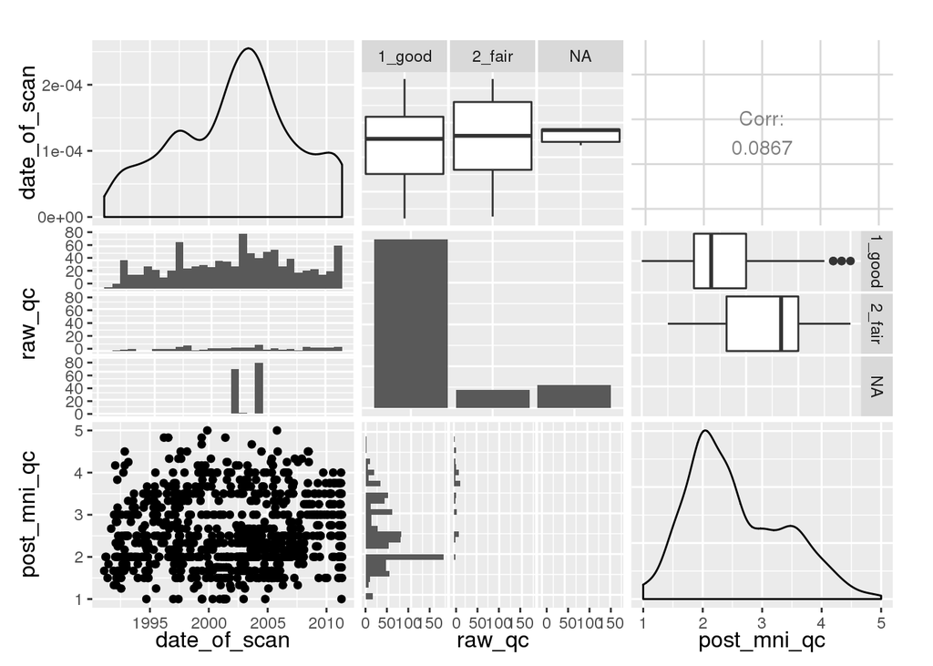

**ScanSeqForPerson** is described as the “sequence number for scans within individual study participant for this dataset”. I took this to mean that as listed below 1131 people had a first scan and 41 subjects had 3 subsequent scans. I think this is wrong though. See the subsequent analysis using MRN

```r
dem_data %>%
  select(scan_seq_for_person) %>%
  table()
```

```
## .
##    1    2    3    4
## 1131   41   41   41
```

There are 545 distinct **MRN** values. Using this it looks like some people got scanned as many as 10 times.

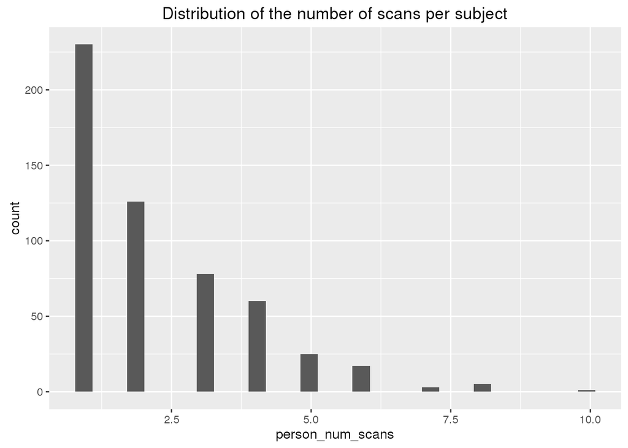

The plot below shows the scans performed over time (with lines connecting a specific MRN). Of the 315 people that have more than 1 data point:

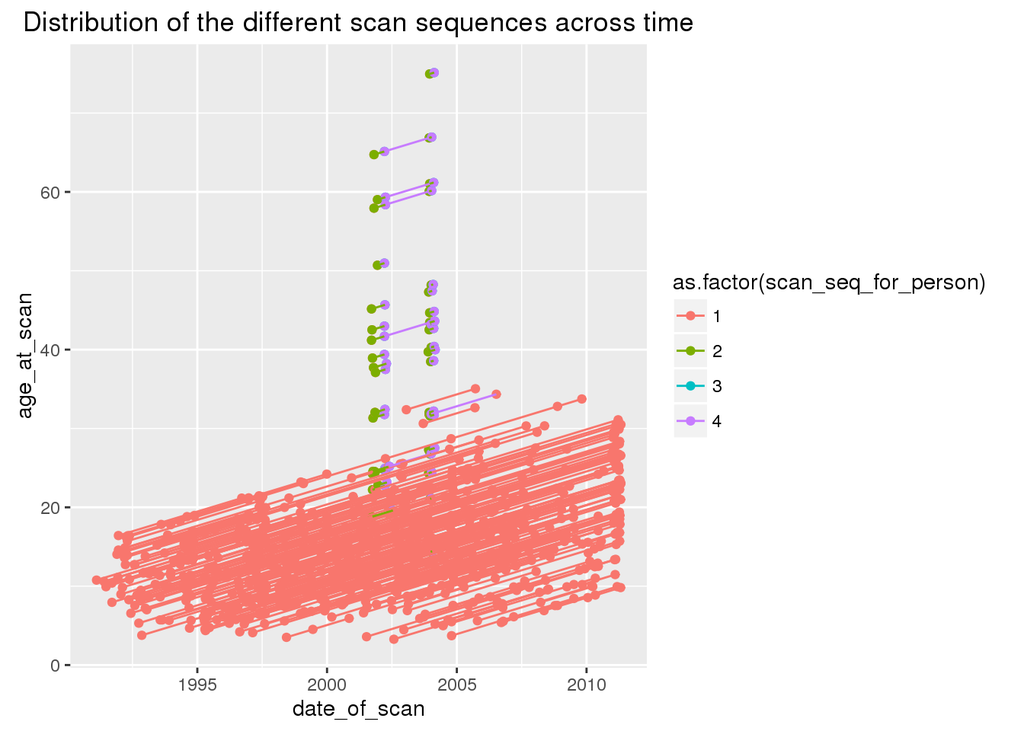

Another metadata variable is the **fam_ID**, descibed as “the family identification number”. These numbers repeat within the dataset at a slightly higher frequency (there are only 393 unique IDs). This is perhaps a number of scans done in the same family. There are lots of fam_IDs that have just 1 scan associated with them and some that have more than 10. As an additional note the **family** variable has 134 unique values (presumably different families have the same name).

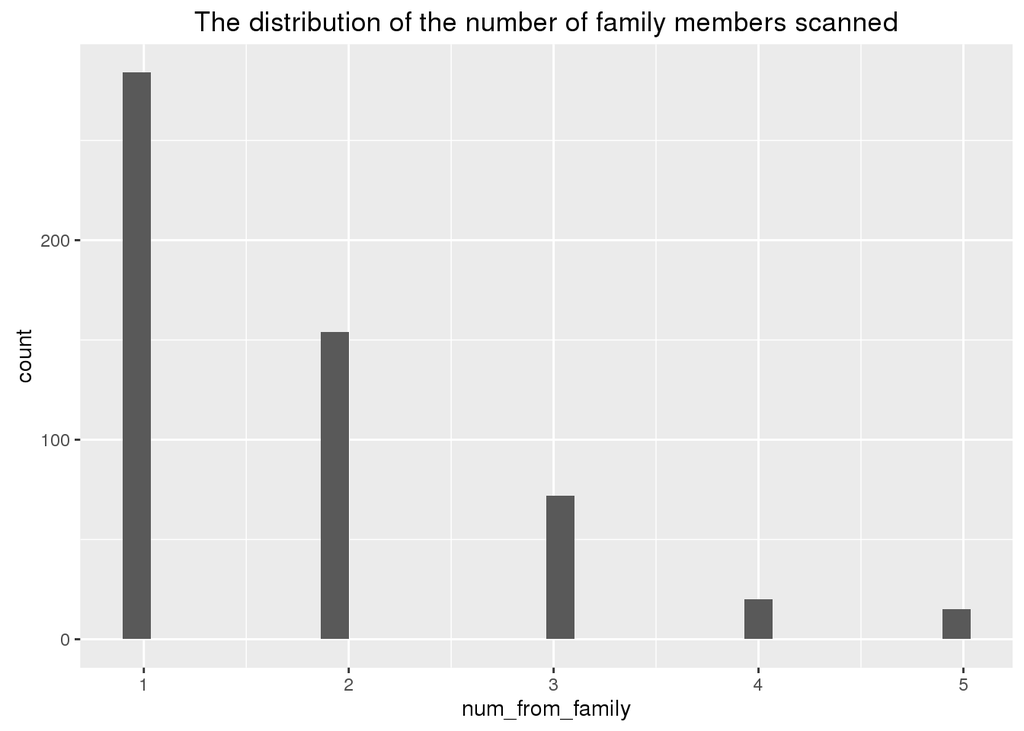

**Scanner_text** gives information on the five scanners used. Is there another location for alternative metadata for this sort of stuff? Embedded in the files?

## A statistical model

The regression coefficient estimates (beta weights) are listed below for the regression of normalized brain volume with respect to age (continuous variable) and gender.

```r
models <- merged_data %>% unnest() %>%
  group_by(struct_name) %>% nest() %>%
  mutate(model= map(data,
                    # Interaction terms are included
                    ~ lm(volume_mm3 ~ tot_intracranial*age_at_scan*sex,
                         data = .))) %>%
  unnest(model %>%
           map(tidy))
```

Structures where gender has an effect with a significance of p<0.01 are reported:

```
## # A tibble: 9 x 4
##              struct_name  term    estimate      p.value
##                   <fctr> <chr>       <dbl>        <dbl>
## 1 non-WM-hypointensities  sexM    72.03027 1.987248e-07
## 2 Left-Lateral-Ventricle  sexM 20593.79582 3.921787e-07
## 3      Left-Inf-Lat-Vent  sexM   833.00233 9.787932e-06
## 4           Optic-Chiasm  sexM   371.61298 2.905417e-05
## 5   Right-choroid-plexus  sexM  1641.97879 2.000512e-04
## 6     Right-Inf-Lat-Vent  sexM   707.73678 3.507113e-04
## 7     WM-hypointensities  sexM  3060.94468 3.693648e-04
## 8                    CSF  sexM  -790.16060 3.033157e-03
## 9          3rd-Ventricle  sexM   737.51763 6.071379e-03
```

Structures where age has an effect with a significance of p<0.05 are reported:

```
## # A tibble: 15 x 4
##                struct_name        term     estimate      p.value
##                     <fctr>       <chr>        <dbl>        <dbl>
## 1             CC_Posterior age_at_scan   34.4711877 1.672916e-07
## 2  Right-Lateral-Ventricle age_at_scan -582.8340166 7.383967e-05
## 3         CC_Mid_Posterior age_at_scan   13.8357156 1.348267e-03
## 4             Optic-Chiasm age_at_scan   11.0956219 1.635424e-03
## 5             Right-vessel age_at_scan   -5.5738883 1.682146e-03
## 6            Right-Putamen age_at_scan  -66.9781855 5.976146e-03
## 7           Right-Pallidum age_at_scan  -22.8039763 7.537563e-03
## 8          CC_Mid_Anterior age_at_scan   11.4771216 1.385476e-02
## 9               CC_Central age_at_scan   12.9425165 1.390492e-02
## 10         Right-VentralDC age_at_scan   37.0069726 1.942200e-02
## 11           5th-Ventricle age_at_scan   -0.4736508 2.469211e-02
## 12          Left-VentralDC age_at_scan   35.1322317 2.591756e-02
## 13   Right-Thalamus-Proper age_at_scan   63.7296360 2.880380e-02
## 14           Left-Pallidum age_at_scan  -22.3135659 3.190524e-02
## 15            Left-Putamen age_at_scan  -54.9085337 3.371724e-02
```

## Plotting the data

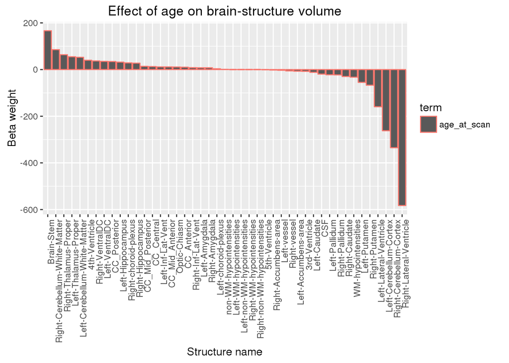

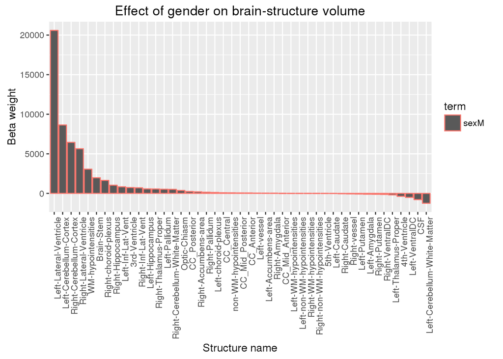

A draft plot of the change in volume over time. Will probably only use scan sequence one, which will also end up filtering out the older subjects.

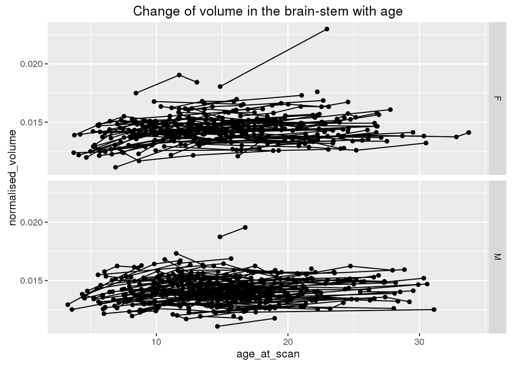

### To do

- Use a linear mixed effects model.
- Reproduce the plot from the publication where the volume of brain structures changes with age.
- Correct for multiple comparison?
- Use rslurm

### Done

- Use total volume as a regressor instead of dividing the volume of each brain structure by this value. Done
- replicate analysis on giedd data
- add interaction terms.
- brain segmentation volume instead of total intracranial? Nope, that has other uses
- take all info from aseg files to avoid searching through them again.
- Check why NA is occurring in some brain regions. Think its just the estimate of the term is 0. Acutally I think the regions just weren’t found (hypointensities).